# Reproducible Research (Project 1)

Eric Pawlakos

June 30, 2016

## Loading and preprocessing the dataset

Begin by downloading the required dataset

```r
if(!file.exists("data")){
  dir.create("data")
}
```

Download and extract the zip file

```r
if(!file.exists("getdata-projectfiles-UCI HAR Dataset.zip")) {
  temp <- tempfile()
  download.file("http://d396qusza40orc.cloudfront.net/repdata%2Fdata%2Factivity.zip",temp)
  unzip(temp)
  unlink(temp)
}
```

Read in the dataset

```r
activity <- read.csv("activity.csv")
```

Preprocessing the data

```r
activity$day <- weekdays(as.Date(activity$date))
activity$DateTime <- as.POSIXct(activity$date, format = "%Y-%m-%d")
```

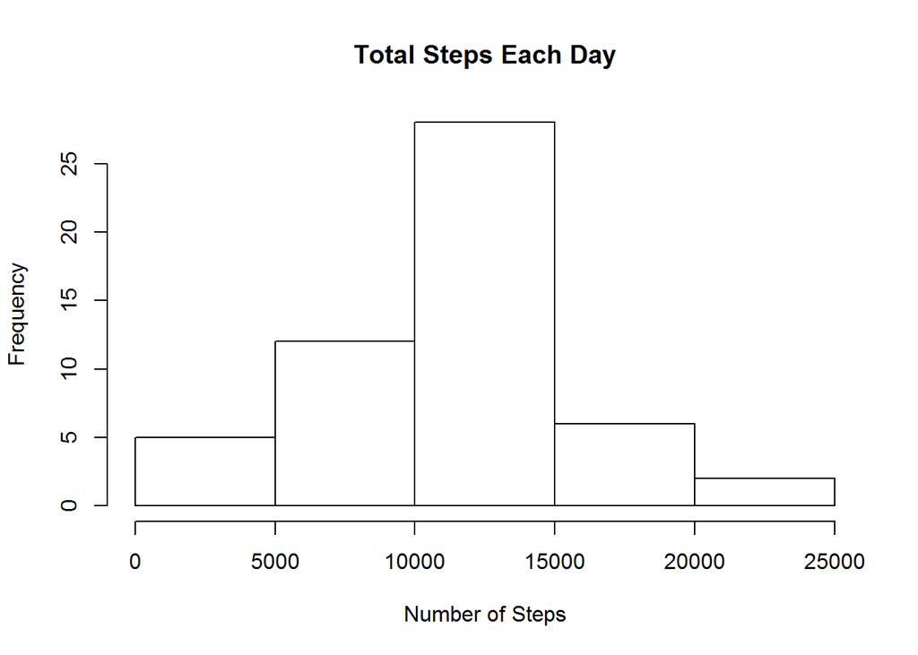

```r
totalsteps <- aggregate(steps ~ date, activity, FUN = sum)
hist(totalsteps$steps, xlab = "Number of Steps", main = "Total Steps Each Day")
```

```r
smean <- mean(totalsteps$steps)
smedian <- median(totalsteps$steps)
```

## What is the average daily pattern?

Make a time series plot (i.e. type = “l”) of the 5-minute interval (x-axis) and the average number of steps taken, averaged across all days (y-axis)

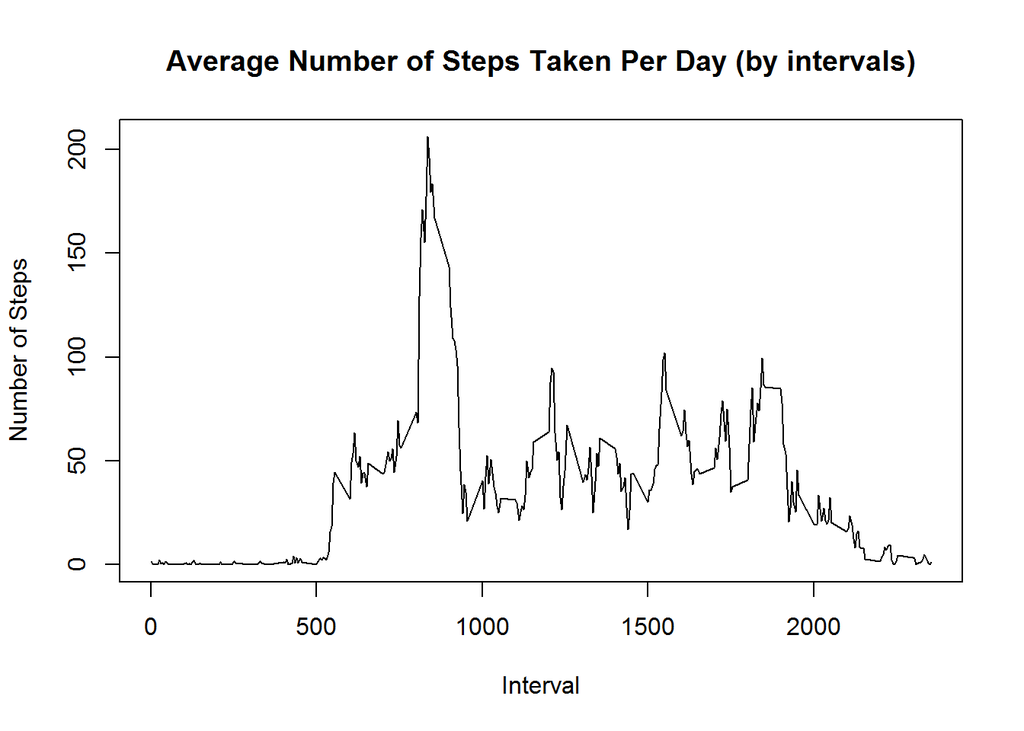

```r
intervalsteps <- aggregate(steps ~ interval, activity, mean)
plot(intervalsteps$interval, intervalsteps$steps, type = "l",
     xlab = "Interval", ylab = "Number of Steps",
     main = "Average Number of Steps Taken Per Day (by intervals)")
```

Which 5-minute interval, on average across all the days in the dataset, contains the maximum number of steps?

```r
intervalmax <- intervalsteps[which.max(intervalsteps$steps), 1]
intervalmax
```

```
## [1] 835
```

## Imputing missing values

Calculate and report the total number of missing values in the dataset (i.e. the total number of rows with NAs)

```r
totalNA <- sum(is.na(activity))
totalNA
```

```
## [1] 2304
```

# Devise a strategy for filling in all of the missing values in the dataset.

```r
activity2 <- activity
NAs <- is.na(activity2$steps)
intervalavg <- tapply(activity2$steps, activity2$interval, mean, na.rm = TRUE,
                      simplify = TRUE)
activity2$steps[NAs] <- intervalavg[as.character(activity2$interval[NAs])]
```

Create a histogram of the imputed data and compare with the original non-imputed data

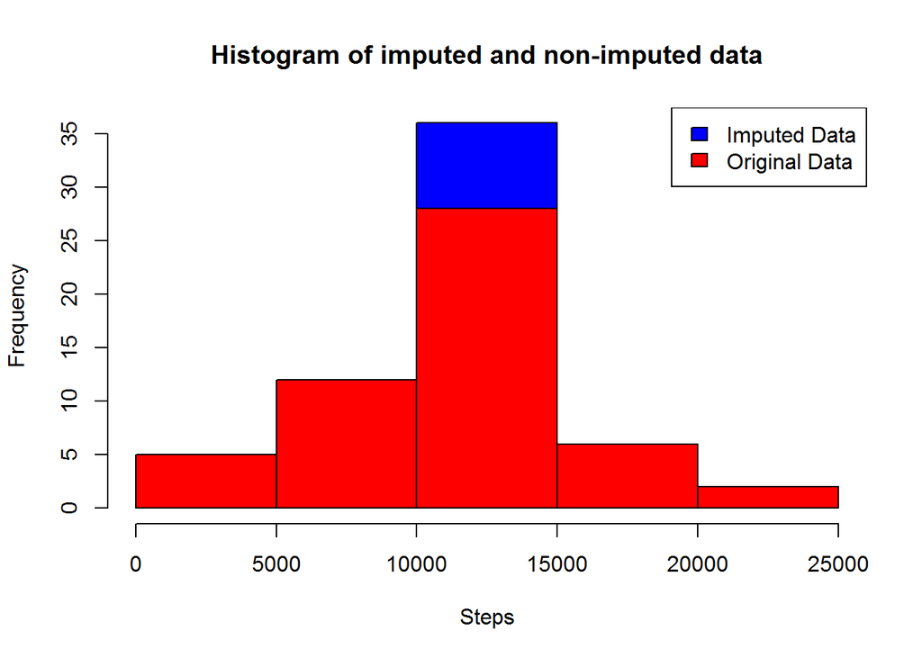

```r
intervalsteps2 <- tapply(activity2$steps, activity2$date, sum, na.rm=TRUE, simplify=T)
hist(intervalsteps2, xlab = "Steps", main = "Histogram of imputed and non-imputed data",
     col = "blue")
hist(totalsteps$steps, col = "red", add = TRUE)
legend("topright", c("Imputed Data", "Original Data"), fill=c("blue", "red"))
```

```r
smean2 <- mean(intervalsteps2)
smedian2 <- median(intervalsteps2)
```

Create a new categorial variable that splits days into if it is a weekday or a weekend.

```r
names(activity2)
```

```
## [1] "steps"    "date"     "interval" "day"      "DateTime"
```

```r
activity2$dayType <- ifelse(activity2$day %in% c("Saturday", "Sunday"),
                            "Weekend", "Weekday")
```

Now we need to create a time series plot using day type as a factor in order to compare steps on weekdays and weekends.

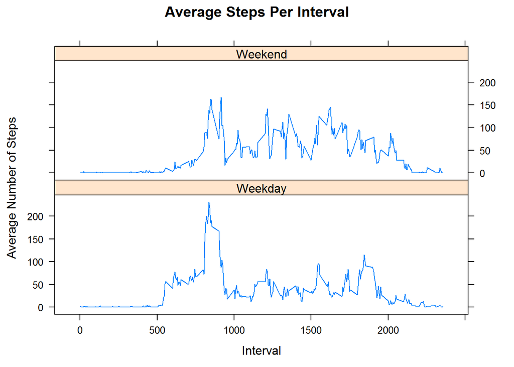

```r
library(lattice)
library(plyr)

interval2 <- ddply(activity2, .(interval, dayType), summarize, Avg = mean(steps))
xyplot(Avg~interval|dayType, data=interval2, type="l",
       layout = c(1,2), xlab="Interval", ylab = "Average Number of Steps",
       main = "Average Steps Per Interval")
```